# Flyback converter

The flyback converter shown in the figure has an input voltage of $20\,$V and an output voltage of $40\,$V. The switching frequency of the converter is $50\,$kHz. The flyback transformer is represented using an ideal transformer with a magnetizing inductance $L_m = 100\,\mu$H. The turns ratio of the transformer is 1:4, the load resistance is $10\,\Omega$, and the output capacitance is $100\,\mu$F.

1. What is the duty cycle of the converter?
2. Plot the current through $L_m$, and determine the peak, rms, and average values.
3. What is the peak-to-peak ripple in the output voltage?
4. Plot the currents through the switch, diode, and capacitor.

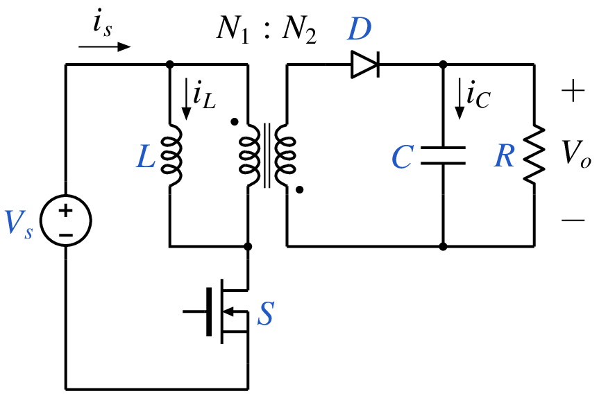

```python
from IPython.display import Image
Image(filename =r'flyback_1_fig_1.png', width=320)
```

```python
# run this cell to view the circuit file.
%pycat flyback_1_orig.in
```

We now replace the strings such as \$Vdc, \$L, with the values of our choice by running the python script given below. It takes an existing circuit file `flyback_1_orig.in` and produces a new circuit file `flyback_1.in`, after replacing \$Vdc, \$L, etc. with values of our choice.

```python
import gseim_calc as calc
s_D = "0.25" # to be changed by user
s_Vdc = "20"
s_L = "100e-6"
s_R = "10"
s_C = "100e-6"
s_N1 = "1"
s_N2 = "4"
s_f_hz = "50e3"

l = [
  ('$D', s_D),
  ('$Vdc', s_Vdc),
  ('$L', s_L),
  ('$R', s_R),
  ('$C', s_C),
  ('$N1', s_N1),
  ('$N2', s_N2),
  ('$f_hz', s_f_hz),
]
calc.replace_strings_1("flyback_1_orig.in", "flyback_1.in", l)
print('flyback_1.in is ready for execution')
```

```
flyback_1.in is ready for execution
```

**Execute the following cell to run GSEIM on flyback_1.in.**

```python
import os
import dos_unix
# uncomment for windows:
#dos_unix.d2u("flyback_1.in")
os.system('run_gseim flyback_1.in')
```

```
Circuit: filename = flyback_1.in
main: calling solve_sss
solve_sss starting: sss_n_st: 2
solve_sss_ex: sss_iter_newton=0, rhs_sss_norm=1.4117e+00, sss_period_1_compute=4.0000e-05
solve_sss_ex: sss_iter_newton=1, rhs_sss_norm=7.2160e-04, sss_period_1_compute=4.0000e-05
solve_sss_ex: sss_iter_newton=2, rhs_sss_norm=1.5804e-05, sss_period_1_compute=4.0000e-05
solve_sss_ex: sss_iter_newton=3, rhs_sss_norm=3.2756e-09, sss_period_1_compute=4.0000e-05
solve_sss_ex: sss_iter_newton=4, rhs_sss_norm=1.1379e-10, sss_period_1_compute=4.0000e-05
solve_sss_ex: sss_iter_newton=5, rhs_sss_norm=1.3817e-14, sss_period_1_compute=4.0000e-05
solve_sss_ex: calling sss_solve_trns_ex for one more trns step
Transient simulation starts...
i=0
GSEIM: Program completed.
```

```
0
```

The circuit file (`flyback_1.in`) is created in the same directory as that used for launching Jupyter notebook. The last step (i.e., running `GSEIM` on `flyback_1.in`) creates a data file called `flyback_1.dat` in the same directory. We can now use the python code below to compute/plot the various quantities of interest.

```
filename: flyback_1.dat
rms inductor current:  1.4218E+01
average inductor current:  1.4215E+01
peak inductor current:  1.4714E+01
peak-to-peak ripple in Vo:  1.3329E-01
```

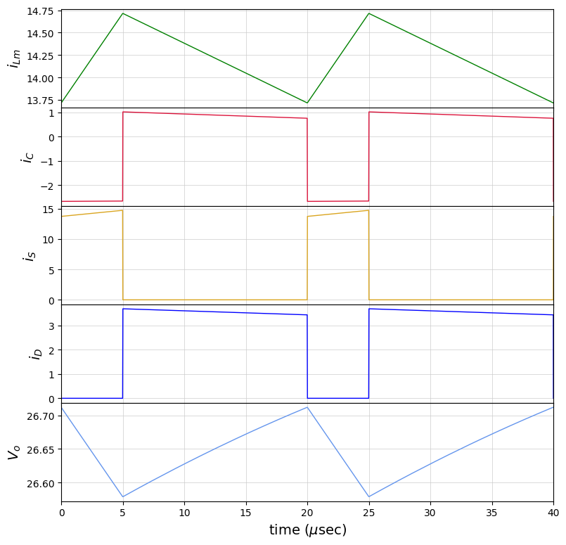

```python
import numpy as np
import matplotlib.pyplot as plt
import gseim_calc as calc
from setsize import set_size

slv = calc.slv("flyback_1.in")

i_slv = 0
i_out = 0
filename = slv.l_filename_all[i_slv][i_out]
print('filename:', filename)
u = np.loadtxt(filename)
t = u[:, 0]

v_out = slv.get_array_double(i_slv,i_out,"v_out",u)
ILm   = slv.get_array_double(i_slv,i_out,"ILm"  ,u)
IS    = slv.get_array_double(i_slv,i_out,"IS"   ,u)
ID    = slv.get_array_double(i_slv,i_out,"ID"   ,u)
IC    = slv.get_array_double(i_slv,i_out,"IC"   ,u)

# since we have stored two cycles, we need to divide the last time point
# by 2 to get the period:

T = t[-1]/2

l_ILm = calc.avg_rms_3a(t, ILm, T, 2.0*T, 1.0e-4*T)

l_ILm_1 = calc.min_max_1(t, ILm, 0.0, 2.0*T)

print('rms inductor current:', "%11.4E"%l_ILm[1])
print('average inductor current:', "%11.4E"%l_ILm[0])
print('peak inductor current:', "%11.4E"%l_ILm_1[1])

l_v_out_1 = calc.min_max_1(t, v_out, 0.0, 2.0*T)
v_out_ptop = l_v_out_1[1] - l_v_out_1[0]
print('peak-to-peak ripple in Vo:', "%11.4E"%v_out_ptop)

color1='green'
color2='crimson'
color3='goldenrod'
color4='blue'
color5='cornflowerblue'

fig, ax = plt.subplots(5, sharex=False)
plt.subplots_adjust(wspace=0, hspace=0.0)

set_size(7, 7, ax[0])

for i in range(5):
    ax[i].set_xlim(left=0, right=2.0*T*1e6)
    ax[i].grid(color='#CCCCCC', linestyle='solid', linewidth=0.5)

ax[0].plot(t*1e6, ILm  , color=color1, linewidth=1.0, label="$i_{Lm}$")
ax[1].plot(t*1e6, IC   , color=color2, linewidth=1.0, label="$i_C$")
ax[2].plot(t*1e6, IS   , color=color3, linewidth=1.0, label="$i_S$")
ax[3].plot(t*1e6, ID   , color=color4, linewidth=1.0, label="$i_D$")
ax[4].plot(t*1e6, v_out, color=color5, linewidth=1.0, label="$V_o$")

ax[0].set_ylabel(r'$i_{Lm}$', fontsize=14)
ax[1].set_ylabel(r'$i_C$'   , fontsize=14)
ax[2].set_ylabel(r'$i_S$'   , fontsize=14)
ax[3].set_ylabel(r'$i_D$'   , fontsize=14)
ax[4].set_ylabel(r'$V_o$'   , fontsize=14)

ax[4].set_xlabel('time (' + r'$\mu$' + 'sec)', fontsize=14)

#ax[0].legend(loc = 'lower right',frameon = True, fontsize = 10, title = None,
#   markerfirst = True, markerscale = 1.0, labelspacing = 0.5, columnspacing = 2.0,
#   prop = {'size' : 12},)

for i in range(4):
    ax[i].tick_params(labelbottom=False)

#plt.tight_layout()
plt.show()
```

This notebook was contributed by **Prof. Nakul Narayanan K**, Govt. Engineering College, Thrissur. He may be contacted at nakul@gectcr.ac.in.